# 1 - Traitement des séries temporelles sous R

Analyse des séries temporelles avec R

Alain Quartier-la-Tente

> L’objectif de ce TP est d’apprendre à manipuler les séries temporelles sous R en utilisant les packages de bases.

Dans R il existe de nombreux packages qui permettent de manipuler les séries temporelles. Pour n’en citer que quelques-uns :  
- Les objets `ts` peuvent être créés à partir du package `stats` ;  
- Les objets `zoo` peuvent être créés à partir du package zoo ;  
- Les objets `xts` peuvent être créés à partir du package xts ;  
- Les objets `tis` peuvent être créés à partir du package tseries ;  
- Les objets `tsibble` peuvent être créés à partir du package tsibble.

tsbox permet quand à lui de facilement passer d’une classe à l’autre.

Ici nous nous concentrerons essentiellement sur les trois premiers : `ts` stocker les séries temporelles, `zoo` et `xts` pour effectuer certaines manipulations supplémentaires.

Les packages suivants seront utilisés :

```r
packages_to_install <- c("zoo", "xts", "dplyr", "tsibble", "lubridate", "XLConnect")

packages <- installed.packages()[,"Package"][! packages_to_install %in% installed.packages()[,"Package"]]
if (length(packages) > 0) {
    install.packages(packages)
}
```

# 1 Manipulation des séries temporelles avec `ts()`

## 1.1 Création d’une série temporelle

La fonction `ts()` permet de créer des objets séries-temporelles à partir un vecteur (ou une matrice). La syntaxe de base est `ts(vector, start=, end=, frequency=)` où `start` et `end` sont la première et la dernière observation, `frequency` est le nombre d’observations par unité de temps (1=annuelle, 2=semestrielle, 4=trimestrielle, 6=bi-mestrielle, 12=mensuelle, etc.).

Par exemple pour créer une série trimestrielle ayant les valeurs de 1 à 10 et commençant en 1959Q2 :

```r
ts(1:10, frequency = 4, start = c(1959, 2)) # 2ème trimestre de 1959
```

```
##      Qtr1 Qtr2 Qtr3 Qtr4
## 1959         1    2    3
## 1960    4    5    6    7
## 1961    8    9   10
```

```r
# Équivalent à
ts(1:10, frequency = 4, start = 1959 + 1/4)
```

```
##      Qtr1 Qtr2 Qtr3 Qtr4
## 1959         1    2    3
## 1960    4    5    6    7
## 1961    8    9   10
```

On peut aussi définir l’objet à partir de sa date de fin :

```r
ts(1:10, frequency = 4, end = c(1959, 2))
```

```
##      Qtr1 Qtr2 Qtr3 Qtr4
## 1957    1    2    3    4
## 1958    5    6    7    8
## 1959    9   10
```

Si l’on directement extraire un sous-ensemble de la série on peut spécifier les paramètres `end` et `start`. Par exemple pour ne garder que les valeurs jusqu’en 1960 inclus :

```r
ts(1:10, frequency = 4, start = c(1959, 2), end = c(1960, 4))
```

```
##      Qtr1 Qtr2 Qtr3 Qtr4
## 1959         1    2    3
## 1960    4    5    6    7
```

Ou alors utiliser la fonction `window` une fois l’objet créé :

```r
ts_object <- ts(1:10, frequency = 4, start = c(1959, 2))
window(ts_object, end = c(1960, 4))
```

```
##      Qtr1 Qtr2 Qtr3 Qtr4
## 1959         1    2    3
## 1960    4    5    6    7
```

On peut récupérer les différents attributs avec les fonctions `start()`, `end()` et `frequency()` :

```r
start(ts_object)
```

```
## [1] 1959    2
```

```r
end(ts_object)
```

```
## [1] 1961    3
```

```r
frequency(ts_object)
```

```
## [1] 4
```

Deux autres fonctions peuvent aussi être utiles : `time()` crée un série-temporelle à partir des dates de notre série-temporelle et `cycle()` donne la position dans le cycle de chaque observation.

```r
time(ts_object)
```

```
##         Qtr1    Qtr2    Qtr3    Qtr4
## 1959         1959.25 1959.50 1959.75
## 1960 1960.00 1960.25 1960.50 1960.75
## 1961 1961.00 1961.25 1961.50
```

```r
cycle(ts_object)
```

```
##      Qtr1 Qtr2 Qtr3 Qtr4
## 1959         2    3    4
## 1960    1    2    3    4
## 1961    1    2    3
```

Extraire toutes les données du 2ème trimestre de l’objet `ts_object`

```r
ts_object[cycle(ts_object) == 2]
```

```
## [1] 1 5 9
```

```r
# Autre option : utiliser la fonction window
window(ts_object, frequency = 1)
```

```
## Time Series:
## Start = 1959.25
## End = 1961.25
## Frequency = 1
## [1] 1 5 9
```

```r
indicatrice <- ts(0, start = 2000, end = 2020, frequency = 12)
window(indicatrice, start = c(2005, 4), end = c(2005, 4)) <- 1
indicatrice
```

```
##      Jan Feb Mar Apr May Jun Jul Aug Sep Oct Nov Dec
## 2000   0   0   0   0   0   0   0   0   0   0   0   0
## 2001   0   0   0   0   0   0   0   0   0   0   0   0
## 2002   0   0   0   0   0   0   0   0   0   0   0   0
## 2003   0   0   0   0   0   0   0   0   0   0   0   0
## 2004   0   0   0   0   0   0   0   0   0   0   0   0
## 2005   0   0   0   1   0   0   0   0   0   0   0   0
## 2006   0   0   0   0   0   0   0   0   0   0   0   0
## 2007   0   0   0   0   0   0   0   0   0   0   0   0
## 2008   0   0   0   0   0   0   0   0   0   0   0   0
## 2009   0   0   0   0   0   0   0   0   0   0   0   0
## 2010   0   0   0   0   0   0   0   0   0   0   0   0
## 2011   0   0   0   0   0   0   0   0   0   0   0   0
## 2012   0   0   0   0   0   0   0   0   0   0   0   0
## 2013   0   0   0   0   0   0   0   0   0   0   0   0
## 2014   0   0   0   0   0   0   0   0   0   0   0   0
## 2015   0   0   0   0   0   0   0   0   0   0   0   0
## 2016   0   0   0   0   0   0   0   0   0   0   0   0
## 2017   0   0   0   0   0   0   0   0   0   0   0   0
## 2018   0   0   0   0   0   0   0   0   0   0   0   0
## 2019   0   0   0   0   0   0   0   0   0   0   0   0
## 2020   0
```

Pour tracer un graphique il suffit maintenant d’utiliser les fonctions `plot()` et `lines()`

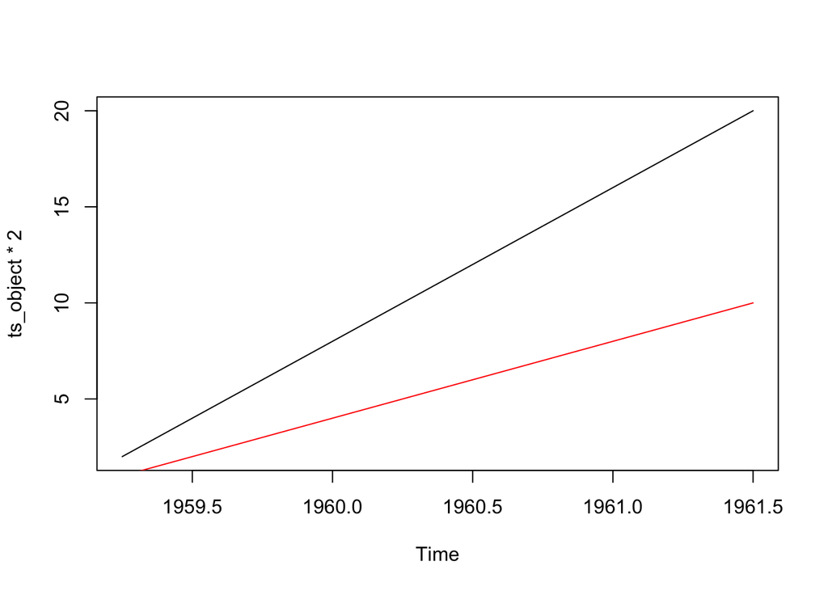

```r
plot(ts_object * 2)
lines(ts_object, col = "red")
```

## 1.2 Séries multivariées

De la même façon que précédemment on peut créer une série temporelle multivariée. Cette fois-ci l’objet créé est à la fois `mts`, `ts` et `matrix`

```r
set.seed(1)
mts <- ts(matrix(rnorm(300), 100, 3), start = c(1961, 1), frequency = 12)
```

On peut accéder à la première variable de la même façon que dans une matrice : par son nom ou son numéro de colonne :

```r
colnames(mts)
```

```
## [1] "Series 1" "Series 2" "Series 3"
```

```r
# mts[,1] # ou de façon équivalente :
mts[, "Series 1"]
```

```
##               Jan          Feb          Mar          Apr          May
## 1961 -0.626453811  0.183643324 -0.835628612  1.595280802  0.329507772
## 1962 -0.621240581 -2.214699887  1.124930918 -0.044933609 -0.016190263
## 1963  0.619825748 -0.056128740 -0.155795507 -1.470752384 -0.478150055
## 1964 -0.394289954 -0.059313397  1.100025372  0.763175748 -0.164523596
## 1965 -0.112346212  0.881107726  0.398105880 -0.612026393  0.341119691
## 1966  2.401617761 -0.039240003  0.689739362  0.028002159 -0.743273209
## 1967  0.610726353 -0.934097632 -1.253633400  0.291446236 -0.443291873
## 1968  0.593946188  0.332950371  1.063099837 -0.304183924  0.370018810
## 1969 -1.276592208 -0.573265414 -1.224612615 -0.473400636
##               Jun          Jul          Aug          Sep          Oct
## 1961 -0.820468384  0.487429052  0.738324705  0.575781352 -0.305388387
## 1962  0.943836211  0.821221195  0.593901321  0.918977372  0.782136301
## 1963  0.417941560  1.358679552 -0.102787727  0.387671612 -0.053805041
## 1964 -0.253361680  0.696963375  0.556663199 -0.688755695 -0.707495157
## 1965 -1.129363096  1.433023702  1.980399899 -0.367221476 -1.044134626
## 1966  0.188792300 -1.804958629  1.465554862  0.153253338  2.172611670
## 1967  0.001105352  0.074341324 -0.589520946 -0.568668733 -0.135178615
## 1968  0.267098791 -0.542520031  1.207867806  1.160402616  0.700213650
## 1969
##               Nov          Dec
## 1961  1.511781168  0.389843236
## 1962  0.074564983 -1.989351696
## 1963 -1.377059557 -0.414994563
## 1964  0.364581962  0.768532925
## 1965  0.569719627 -0.135054604
## 1966  0.475509529 -0.709946431
## 1967  1.178086997 -1.523566800
## 1968  1.586833455  0.558486426
## 1969
```

Et avec les même fonctions que pour les matrices on peut récupérer les noms des colonnes (`colnames`), le nombre de variables (`ncol`), etc.

Une source classique d’erreur est de manipuler des séries-temporelles uni et multivariées et de vouloir utiliser les fonctions liées aux matrices sur les séries univariées. Par exemple, `colnames(ts_object)` renverra toujours l’objet `NULL`. Une solution est de tester si l’objet est multivarié avec la fonction `is.mts()`.

## 1.3 Manipulation basiques

Pour concaténer plusieurs séries temporelles, les fonctions deux fonctions suivantes peuvent `ts.union()` et `ts.intersect()`.

```r
ts_object2 <- ts(1:10, frequency = 4, start = c(1960, 1))
ts.union(ts_object, ts_object2) # on garde toute la couverture temporelle en rajoutant des NA
```

```
##         ts_object ts_object2
## 1959 Q2         1         NA
## 1959 Q3         2         NA
## 1959 Q4         3         NA
## 1960 Q1         4          1
## 1960 Q2         5          2
## 1960 Q3         6          3
## 1960 Q4         7          4
## 1961 Q1         8          5
## 1961 Q2         9          6
## 1961 Q3        10          7
## 1961 Q4        NA          8
## 1962 Q1        NA          9
## 1962 Q2        NA         10
```

```r
ts.intersect(ts_object, ts_object2) # on ne garde que les périodes communes
```

```
##         ts_object ts_object2
## 1960 Q1         4          1
## 1960 Q2         5          2
## 1960 Q3         6          3
## 1960 Q4         7          4
## 1961 Q1         8          5
## 1961 Q2         9          6
## 1961 Q3        10          7
```

On va maintenant utiliser la série d’indice de production industrielle de la France (CVS-CJO) :

```r
ipi_fr_manuf <- ts(c(94.2, 96.69, 95.66, 95.06, 95.96, 93.97, 94.16, 93.4,
94.12, 94.29, 92.42, 93.01, 94.98, 93.31, 93.76, 93.06, 91.93,
93.41, 91.68, 92.98, 93.42, 92.39, 93.74, 92.69, 93.12, 92.57,
93.49, 92.59, 92.85, 91.74, 91.23, 91.53, 90.08, 90.47, 89.97,
88.44, 88.66, 87.86, 87.38, 87.42, 87.14, 86.24, 87.67, 86.86,
87.2, 87.68, 85.93, 86.25, 88.14, 87.71, 88.21, 89.59, 90.38,
90.76, 91.67, 92.18, 91.79, 93.02, 94.54, 94.04, 94.17, 94.56,
93.94, 94.29, 93.59, 94.34, 94.79, 94.04, 94.62, 93.51, 92.59,
94.9, 93.89, 93.19, 94.19, 93.67, 95.19, 94.72, 92.82, 95.49,
95.13, 94.21, 95.42, 95.34, 94.39, 96.09, 97.14, 100.02, 97.84,
98.59, 98.72, 102.9, 100.51, 103.23, 100.91, 103.1, 103.21, 103.76,
102.15, 103.37, 104.98, 104.21, 105.32, 102.65, 104.34, 104.07,
104.39, 103.62, 104.75, 103.36, 103.8, 104.89, 105.49, 106.69,
106.91, 104.6, 107.76, 109.36, 109.26, 108.33, 109.12, 109.6,
110.2, 110.81, 112.57, 110.92, 112.15, 110.86, 111.53, 112.75,
112.67, 114.3, 113.32, 114.09, 114.65, 112.12, 113.06, 113.27,
111.34, 114.36, 111.94, 112.04, 109.81, 110.12, 110.98, 111.91,
112.23, 112.86, 111.23, 111.13, 109.96, 112.59, 110.62, 109.69,
111.26, 108.05, 110.05, 110.39, 110.92, 110.7, 107.72, 107.26,
109.22, 108.78, 108.66, 110.62, 108.8, 109.42, 110.12, 111.6,
110.61, 111, 110.22, 111.69, 112.3, 107.68, 111.92, 112.66, 110.38,
110.74, 113.16, 111.04, 108.72, 112, 110.35, 110.3, 110.21, 109.04,
112.63, 109.26, 113.55, 112.07, 111.16, 110.64, 112.98, 111.54,
114.46, 114.28, 112.29, 111.52, 113.52, 112.84, 112.1, 114.24,
113.24, 114.18, 114.73, 113.28, 115.9, 114.88, 115.04, 115.72,
112.57, 115.17, 113.71, 113.82, 115.29, 116.48, 114.36, 116.12,
111.24, 110.64, 111.49, 109.8, 109.25, 107.21, 100.8, 99.34,
94.87, 93.66, 92.19, 92.2, 93.49, 95.23, 94.71, 96.27, 97.09,
96.3, 97.66, 96.56, 97.12, 96.6, 98.78, 98.7, 99.27, 99.03, 99.69,
98.63, 99.98, 99.7, 100.82, 101.79, 104.09, 105.03, 103.59, 102.21,
105.56, 101.55, 103.08, 101.93, 101.22, 101.5, 104.35, 102.1,
101.05, 100.14, 101.87, 100.16, 99.79, 99.16, 100.01, 101.92,
100.11, 97.66, 97.59, 99.12, 98.02, 98.55, 98.78, 100.31, 100.31,
99.64, 98.56, 98.37, 98.54, 99.16, 100.35, 99.27, 98.24, 99.95,
99.43, 99.53, 96.53, 99.06, 100.11, 98.2, 99.17, 97.91, 96.93,
99.45, 99.02, 99.38, 99.74, 99.38, 100.85, 100.02, 98.66, 100.22,
101.23, 100.64, 99.94, 100.92, 102.39, 100.8, 99.54, 100.73,
99.76, 99.07, 99.77, 101.63, 100.4, 99.4, 102.76, 100.97, 100.16,
101.11, 102.62, 101.82, 103.7, 103.02, 103.59, 103.54, 104.38,
105.57, 105.52, 105.93, 103.59, 102.87, 103.82, 103.83, 102.5,
104.23, 104.04, 104.61, 103.38, 104.22, 103.42, 103.7, 104.93,
105.75, 104.38, 104.29, 105.98, 103.72, 104.07, 103.1, 103.88,
104.37), start = 1990, frequency = 12)
```

Pour calculer la série retardée/avancée, il suffit d’utiliser la fonction `lag()` :

```r
# série retardée d'un mois : en février 2010 on a la valeur de janvier 2010
lag(ipi_fr_manuf, k = -1)
```

La fonction `diff` permet de calculer la différence entre deux périodes

```r
diff(ipi_fr_manuf, k = 1)
```

Écrire une fonction `ev()` qui calcule l’évolution mensuelle si la série en entrée est mensuelle, l’évolution trimestrielle si la série en entrée est trimestrielle, etc.

```r
ev <- function(x){
  result <- (x/stats::lag(x, k = -1) - 1) * 100
  return(result)
}
# Ou de manière équivalente :
ev2 <- function(x){
  # Attention ici c'est bien k = 1 dans la fonction diff
  # et k = -1 dans la fonction lag
  result <- (diff(x, k = 1) /lag(x, k = -1)) * 100
  return(result)
}

#################################################
# Remarque : pour des raisons informatiques ces deux fonctions ne donnent pas exactement
# le même résultat. C'est un problème récurrent lorsque l'on
# souhaite tester l'égalité entre deux séries temporelles :
all (ev(ipi_fr_manuf) == ev2(ipi_fr_manuf))
```

```
## [1] FALSE
```

```r
# Une solution est plutôt d'utiliser la fonction all.equal():
isTRUE(all.equal(ev(ipi_fr_manuf), ev2(ipi_fr_manuf)))
```

```
## [1] TRUE
```

# 2 Utilisation de `xts` et `zoo`

## 2.1 Utilisation de `xts`

Un des avantages du package `xts` est qu’il permet d’appliquer une fonction à chaque période d’une série temporelle (par exemple à toutes les données trimestrielles, annuelles, etc.). Il s’agit des fonctions `apply.monthly()`, `apply.quarterly()`, `apply.yearly()`, etc. Pour cela il faut auparavant convertir les données au format `xts`.  
Par exemple pour calculer la moyenne annuelle :

```r
library(xts)
moy_an <- apply.yearly(as.xts(ipi_fr_manuf), mean)
moy_an
```

```
##               [,1]
## déc 1990  94.41167
## déc 1991  93.11250
## déc 1992  91.50667
## déc 1993  87.19083
## déc 1994  91.00250
## déc 1995  94.11167
## déc 1996  94.43833
## déc 1997  99.45333
## déc 1998 103.83917
## déc 1999 106.26667
## déc 2000 111.45667
## déc 2001 112.51000
## déc 2002 111.04250
## déc 2003 109.37833
## déc 2004 110.91000
## déc 2005 111.02750
## déc 2006 112.63083
## déc 2007 114.35333
## déc 2008 110.16833
## déc 2009  95.01917
## déc 2010  99.17583
## déc 2011 103.01750
## déc 2012  99.88167
## déc 2013  99.15500
## déc 2014  98.70917
## déc 2015 100.00000
## déc 2016 100.60167
## déc 2017 103.41333
## déc 2018 103.68417
## oct 2019 104.44700
```

Calculer l’évolution trimestrielle de `ipi_fr_manuf`.

```r
# Tout d'abord on prolonge l'IPI par des valeurs manquantes jusqu'à la fin
# de l'année, sinon la dernière somme sur le trimestre est fausse.
ipi_fr_manuf_prolonge <- window(ipi_fr_manuf, end = c(2019, 12), extend = TRUE)

somme_trim <- apply.quarterly(as.xts(ipi_fr_manuf_prolonge), sum)
# Attention la fonction lag n'agit pas pareil pour les objets xts et ts :
# il faut ici utiliser l'option k = 1
evol_trim <- (somme_trim/lag(somme_trim, k = 1) - 1) * 100

# On peut utiliser la fonction format()
# si l'on veut convertir automatiquement en un objet ts
start_year <- as.numeric(format(start(evol_trim), "%Y"))
start_quarter <- as.numeric(substr(quarters(start(evol_trim)), 2, 2))
ts(evol_trim, start = c(start_year, start_quarter), frequency = 4)
```

```
##             Qtr1        Qtr2        Qtr3        Qtr4
## 1990          NA -0.54440761 -1.16144426 -0.69582505
## 1991  0.83297583 -1.29409679 -0.11494253  0.26611047
## 1992  0.12911556 -0.71638370 -1.56576954 -1.45140009
## 1993 -1.85212734 -1.17468738  0.35659509 -0.71447675
## 1994  1.61625491  2.52594107  1.81361504  2.16224060
## 1995  0.37997159 -0.15919624  0.43583020 -0.86434997
## 1996  0.09608541  0.82127493 -0.04936878  0.53979678
## 1997  0.92992245  3.07002295  1.91600607  1.69132493
## 1998  0.61189949  1.11283644 -0.07998464 -0.07364478
## 1999 -0.05447321  1.65432336  0.69385309  2.40548752
## 2000  0.60253861  1.63565609  0.07179180  1.54839481
## 2001  0.68880254 -1.05537040 -0.23932634 -1.67930340
## 2002  0.94888092  0.02984006 -0.61153869 -1.25161329
## 2003  0.71732523 -1.71414775  0.30090887  0.66736056
```

[output cut: 16 more lines]

On aurait en fait pu le faire directement avec les fonctions de base R ! Par contre la situation aurait été plus compliquée avec des données haute fréquence (du type journalières) non gérées par `ts` :

```r
aggregate(ipi_fr_manuf, nfrequency = 4,
          FUN = sum)
```

```
##        Qtr1   Qtr2   Qtr3   Qtr4
## 1990 286.55 284.99 281.68 279.72
## 1991 282.05 278.40 278.08 278.82
## 1992 279.18 277.18 272.84 268.88
## 1993 263.90 260.80 261.73 259.86
## 1994 264.06 270.73 275.64 281.60
## 1995 282.67 282.22 283.45 281.00
## 1996 281.27 283.58 283.44 284.97
## 1997 287.62 296.45 302.13 307.24
## 1998 309.12 312.56 312.31 312.08
## 1999 311.91 317.07 319.27 326.95
## 2000 328.92 334.30 334.54 339.72
## 2001 342.06 338.45 337.64 331.97
## 2002 335.12 335.22 333.17 329.00
## 2003 331.36 325.68 326.66 328.84
```

[output cut: 16 more lines]

## 2.2 Utilisation de `zoo`

Le package `zoo` donne un ensemble d’outils qui permettent de manipuler les séries-temporelles. De nombreux packages (dont `xts`) sont d’ailleurs basés sur ce format. Il permet notamment de faire des imputations de données manquantes selon différentes fonctions (toutes les fonctions commençant par `na.`) et de mieux gérer le format des dates associées aux séries temporelles (ce qui permet de faire des manipulations avec la fonction `format`, ce qui permet par exemple plus facilement exporter des séries temporelles sous Excel). Le calcul de l’évolution trimestrielle aurait par exemple pu être faite avec ce package :

```r
somme_trim <- aggregate(as.zoo(ipi_fr_manuf_prolonge), yearqtr, sum)
somme_trim <- as.ts(somme_trim) #La conversion en ts est plus simple depuis un objet zoo
evol_trim <- ev(somme_trim)
evol_trim
```

```
##             Qtr1        Qtr2        Qtr3        Qtr4
## 1990             -0.54440761 -1.16144426 -0.69582505
## 1991  0.83297583 -1.29409679 -0.11494253  0.26611047
## 1992  0.12911556 -0.71638370 -1.56576954 -1.45140009
## 1993 -1.85212734 -1.17468738  0.35659509 -0.71447675
## 1994  1.61625491  2.52594107  1.81361504  2.16224060
## 1995  0.37997159 -0.15919624  0.43583020 -0.86434997
## 1996  0.09608541  0.82127493 -0.04936878  0.53979678
## 1997  0.92992245  3.07002295  1.91600607  1.69132493
## 1998  0.61189949  1.11283644 -0.07998464 -0.07364478
## 1999 -0.05447321  1.65432336  0.69385309  2.40548752
## 2000  0.60253861  1.63565609  0.07179180  1.54839481
## 2001  0.68880254 -1.05537040 -0.23932634 -1.67930340
## 2002  0.94888092  0.02984006 -0.61153869 -1.25161329
## 2003  0.71732523 -1.71414775  0.30090887  0.66736056
```

[output cut: 16 more lines]

Pour le prochain exercice, utiliser la série suivante :

```r
serie_avec_NA <- ts(c(NA, NA, NA, NA, NA, NA, NA, NA, NA, NA, NA, NA, 0, 0, 0, 0,
  0, 0, 0, 0, 0, 0, 0, 0, 0, 0, 0, 0, 0, 0, 0, 0, 0, 0, 0, 0, NA,
  NA, NA, NA, NA, NA, NA, NA, NA, NA, NA, NA, NA, NA, NA, NA, NA,
  NA, NA, NA, NA, NA, NA, NA, 1, 1, 1, 1, 1, 1, 1, 1, 1, 1, 1,
  1, 1, 1, 1, 1, 1, 1, 1, 1, 1, 1, 1, 1, NA, NA, NA, NA, NA, NA,
  NA, NA, NA, NA, NA, NA), start = 2000, frequency = 12)
```

Sur la série `serie_avec_NA`, utiliser les différentes fonctions du package `zoo` pour : 1. Enlever les valeurs manquantes au début de la série ; 2. Remplacer les valeurs manquantes à la fin de la série par la dernière valeur observée. 3. Interpoler de manière linéaire les valeurs manquantes entre les 0 et les 1.

Les trois fonctions à utiliser sont : `na.trim()`, `na.locf` et `na.approx()`.

```r
# D'abord on enlève les valeurs manquantes au début de la série
etape_1 <- na.trim(serie_avec_NA, sides = "left")
etape_1
```

```
##      Jan Feb Mar Apr May Jun Jul Aug Sep Oct Nov Dec
## 2001   0   0   0   0   0   0   0   0   0   0   0   0
## 2002   0   0   0   0   0   0   0   0   0   0   0   0
## 2003  NA  NA  NA  NA  NA  NA  NA  NA  NA  NA  NA  NA
## 2004  NA  NA  NA  NA  NA  NA  NA  NA  NA  NA  NA  NA
## 2005   1   1   1   1   1   1   1   1   1   1   1   1
## 2006   1   1   1   1   1   1   1   1   1   1   1   1
## 2007  NA  NA  NA  NA  NA  NA  NA  NA  NA  NA  NA  NA
```

```r
# Ensuite on interpole
etape_2 <- na.approx(etape_1, na.rm = FALSE)
etape_2
```

```
##       Jan  Feb  Mar  Apr  May  Jun  Jul  Aug  Sep  Oct  Nov  Dec
## 2001 0.00 0.00 0.00 0.00 0.00 0.00 0.00 0.00 0.00 0.00 0.00 0.00
## 2002 0.00 0.00 0.00 0.00 0.00 0.00 0.00 0.00 0.00 0.00 0.00 0.00
## 2003 0.04 0.08 0.12 0.16 0.20 0.24 0.28 0.32 0.36 0.40 0.44 0.48
## 2004 0.52 0.56 0.60 0.64 0.68 0.72 0.76 0.80 0.84 0.88 0.92 0.96
## 2005 1.00 1.00 1.00 1.00 1.00 1.00 1.00 1.00 1.00 1.00 1.00 1.00
## 2006 1.00 1.00 1.00 1.00 1.00 1.00 1.00 1.00 1.00 1.00 1.00 1.00
## 2007   NA   NA   NA   NA   NA   NA   NA   NA   NA   NA   NA   NA
```

```r
# Enfin on remplace les valeurs à la fin de la série
etape_3 <- na.locf(etape_2)
etape_3
```

```
##       Jan  Feb  Mar  Apr  May  Jun  Jul  Aug  Sep  Oct  Nov  Dec
## 2001 0.00 0.00 0.00 0.00 0.00 0.00 0.00 0.00 0.00 0.00 0.00 0.00
## 2002 0.00 0.00 0.00 0.00 0.00 0.00 0.00 0.00 0.00 0.00 0.00 0.00
## 2003 0.04 0.08 0.12 0.16 0.20 0.24 0.28 0.32 0.36 0.40 0.44 0.48
## 2004 0.52 0.56 0.60 0.64 0.68 0.72 0.76 0.80 0.84 0.88 0.92 0.96
## 2005 1.00 1.00 1.00 1.00 1.00 1.00 1.00 1.00 1.00 1.00 1.00 1.00
## 2006 1.00 1.00 1.00 1.00 1.00 1.00 1.00 1.00 1.00 1.00 1.00 1.00
## 2007 1.00 1.00 1.00 1.00 1.00 1.00 1.00 1.00 1.00 1.00 1.00 1.00
```

À l’aide des fonctions `as.yearmon()` et `format()`, créer un data.frame contenant une colonne “date” qui contient les dates au format JJ/MM/YYYY et une deuxième colonnes avec les valeurs de `ipi_fr_manuf`.

La fonction `as.yearmon()` doit être appliquée sur `time(ipi_fr_manuf)`. Pour la fonction `format` regarder l’aide `?format.Date`.

```r
dates <- as.yearmon(time(ipi_fr_manuf))
dates <- format(dates, "%d/%m/%Y")
donnees_formatees <- data.frame(date = dates, ipi = ipi_fr_manuf)
head(donnees_formatees)
```

```
##         date   ipi
## 1 01/01/1990 94.20
## 2 01/02/1990 96.69
## 3 01/03/1990 95.66
## 4 01/04/1990 95.06
## 5 01/05/1990 95.96
## 6 01/06/1990 93.97
```

Il peut également être utile d’exporter un objet R `ts` ou `mts` vers un fichier Excel, tout en rajoutant une colonne “date” qui sera au format date. Ci-dessous un exemple en utilisant le package XLConnect :

```r
library(XLConnect)
ts2xls <- function(x, file, sheet="Feuille 1", format = "dd/mm/yyyy"){
  wb <- loadWorkbook(file, create = TRUE)
  createSheet(wb, sheet)
  if(is.mts(x)){
    col <- c("date", colnames(x))
  }else{
    col <- c("date", "x")
  }
  # Le titre
  writeWorksheet(wb,matrix(col,nrow = 1),
                 sheet = sheet,startCol = 1,startRow =1,
                 header = FALSE)

  # Petit trick pour que la colonne date soit au format date d'Excel
  csDate <- getOrCreateCellStyle(wb, name = "date")
  setDataFormat(csDate, format = format)
  date <- as.Date(format(zoo::as.Date((time(x))), "%d/%m/%Y"),
                  "%d/%m/%Y")
  writeWorksheet(wb,date,sheet = sheet,
                 startCol = 1,startRow = 2,
                 header = FALSE)
  setCellStyle(wb, sheet = sheet, row = seq_along(date)+1,
               col = 1,
               cellstyle = csDate)
  # Fin colonne date

  # Autres colonnes
  writeWorksheet(wb,x,sheet = sheet,startCol = 2,startRow = 2,
                 header = FALSE)
  setColumnWidth(wb, sheet, column = seq_along(col), width = -1)
  saveWorkbook(wb, file)
}
```

# 3 Manipulation avec `tsibble`

Le format `tsibble` est un autre format de gestion des séries temporelles

```r
library(tsibble)
mts_tsibble <- as_tsibble(mts)
ipi_tsibble <- as_tsibble(ipi_fr_manuf)
```

Calculer les moyennes trimestrielles de chaque série de `mts_tsibble` et `ipi_tsibble`.

Il faut utiliser à la fois `index_by` et `group_by_key()`.

```r
library(dplyr)
mts_tsibble %>%
    group_by_key() %>%
    index_by(date = ~ yearquarter(.)) %>%
    summarise(moy = mean(value))
```

```
## # A tsibble: 102 x 3 [1Q]
## # Key:       key [3]
##    key         date    moy
##    <chr>      <qtr>  <dbl>
##  1 Series 1 1961 Q1 -0.426
##  2 Series 1 1961 Q2  0.368
##  3 Series 1 1961 Q3  0.601
##  4 Series 1 1961 Q4  0.532
##  5 Series 1 1962 Q1 -0.570
##  6 Series 1 1962 Q2  0.294
##  7 Series 1 1962 Q3  0.778
##  8 Series 1 1962 Q4 -0.378
##  9 Series 1 1963 Q1  0.136
## 10 Series 1 1963 Q2 -0.510
## # … with 92 more rows
```

```r
ipi_tsibble %>%
    group_by_key() %>%
    index_by(date = ~ yearquarter(.)) %>%
    summarise(moy = mean(value))
```

```
## # A tsibble: 120 x 2 [1Q]
##       date   moy
##      <qtr> <dbl>
##  1 1990 Q1  95.5
##  2 1990 Q2  95.0
##  3 1990 Q3  93.9
##  4 1990 Q4  93.2
##  5 1991 Q1  94.0
##  6 1991 Q2  92.8
##  7 1991 Q3  92.7
##  8 1991 Q4  92.9
##  9 1992 Q1  93.1
## 10 1992 Q2  92.4
## # … with 110 more rows
```

1. En utilisant la fonction `dplyr::full_join()`, créer un objet `tsibble` contenant les valeurs de `mts_tsibble` et `ipi_tsibble`.
2. Comparer les résultats avec `dplyr::left_join()` et `dplyr::right_join()`.
3. Quelle serait l’équivalent de `ts.intersect()` et `ts.union()` ?

```r
mts_tsibble %>%  full_join(ipi_tsibble, by = "index") # comme ts.union()
```

```
## # A tsibble: 658 x 4 [1M]
## # Key:       key [4]
##       index key      value.x value.y
##       <mth> <chr>      <dbl>   <dbl>
##  1 1961 jan Series 1  -0.626      NA
##  2 1961 fév Series 1   0.184      NA
##  3 1961 mar Series 1  -0.836      NA
##  4 1961 avr Series 1   1.60       NA
##  5 1961 mai Series 1   0.330      NA
##  6 1961 jui Series 1  -0.820      NA
##  7 1961 jul Series 1   0.487      NA
##  8 1961 aoû Series 1   0.738      NA
##  9 1961 sep Series 1   0.576      NA
## 10 1961 oct Series 1  -0.305      NA
## # … with 648 more rows
```

```r
mts_tsibble %>%  left_join(ipi_tsibble, by = "index")
```

```
## # A tsibble: 300 x 4 [1M]
## # Key:       key [3]
##       index key      value.x value.y
##       <mth> <chr>      <dbl>   <dbl>
##  1 1961 jan Series 1  -0.626      NA
##  2 1961 fév Series 1   0.184      NA
##  3 1961 mar Series 1  -0.836      NA
##  4 1961 avr Series 1   1.60       NA
##  5 1961 mai Series 1   0.330      NA
##  6 1961 jui Series 1  -0.820      NA
##  7 1961 jul Series 1   0.487      NA
##  8 1961 aoû Series 1   0.738      NA
##  9 1961 sep Series 1   0.576      NA
## 10 1961 oct Series 1  -0.305      NA
## # … with 290 more rows
```

```r
mts_tsibble %>%  right_join(ipi_tsibble, by = "index")
```

```
## # A tsibble: 358 x 4 [1M]
## # Key:       key [1]
##       index key   value.x value.y
##       <mth> <chr>   <dbl>   <dbl>
##  1 1990 jan <NA>       NA    94.2
##  2 1990 fév <NA>       NA    96.7
##  3 1990 mar <NA>       NA    95.7
##  4 1990 avr <NA>       NA    95.1
##  5 1990 mai <NA>       NA    96.0
##  6 1990 jui <NA>       NA    94.0
##  7 1990 jul <NA>       NA    94.2
##  8 1990 aoû <NA>       NA    93.4
##  9 1990 sep <NA>       NA    94.1
## 10 1990 oct <NA>       NA    94.3
## # … with 348 more rows
```

```r
mts_tsibble %>%  inner_join(ipi_tsibble, by = "index") # ts.intersect
```

```
## # A tsibble: 0 x 4 [?]
## # Key:       key [0]
## # … with 4 variables: index <mth>, key <chr>, value.x <dbl>, value.y <dbl>
```

Les *index* vont être des dates : on peut facilement les manipuler en utilisant le package `lubdridate`. Par exemple pour ne que garder que les dates à partir de l’année 2000 :

```r
library(lubridate)
ipi_tsibble %>%
    filter(year(index) >= 2000)
```

```
## # A tsibble: 238 x 2 [1M]
##       index value
##       <mth> <dbl>
##  1 2000 jan  109.
##  2 2000 fév  110.
##  3 2000 mar  110.
##  4 2000 avr  111.
##  5 2000 mai  113.
##  6 2000 jui  111.
##  7 2000 jul  112.
##  8 2000 aoû  111.
##  9 2000 sep  112.
## 10 2000 oct  113.
## # … with 228 more rows
```

```r
ipi_tsibble %>%
    filter(index >= make_yearmonth(2000,6))
```

```
## # A tsibble: 233 x 2 [1M]
##       index value
##       <mth> <dbl>
##  1 2000 jui  111.
##  2 2000 jul  112.
##  3 2000 aoû  111.
##  4 2000 sep  112.
##  5 2000 oct  113.
##  6 2000 nov  113.
##  7 2000 déc  114.
##  8 2001 jan  113.
##  9 2001 fév  114.
## 10 2001 mar  115.
## # … with 223 more rows
```

À l’aide du package `lubridate`, extraire toutes les données du mois de janvier et juillet de l’objet `ipi_tsibble`.

```r
# regarder ce que donne
ipi_tsibble %>% mutate(month = lubridate::month(index))
```

```
## # A tsibble: 358 x 3 [1M]
##       index value month
##       <mth> <dbl> <dbl>
##  1 1990 jan  94.2     1
##  2 1990 fév  96.7     2
##  3 1990 mar  95.7     3
##  4 1990 avr  95.1     4
##  5 1990 mai  96.0     5
##  6 1990 jui  94.0     6
##  7 1990 jul  94.2     7
##  8 1990 aoû  93.4     8
##  9 1990 sep  94.1     9
## 10 1990 oct  94.3    10
## # … with 348 more rows
```

```r
library(lubridate)
ipi_tsibble %>%
    filter(month(index) %in% c(1,7))
```

```
## # A tsibble: 60 x 2 [1M]
##       index value
##       <mth> <dbl>
##  1 1990 jan  94.2
##  2 1990 jul  94.2
##  3 1991 jan  95.0
##  4 1991 jul  91.7
##  5 1992 jan  93.1
##  6 1992 jul  91.2
##  7 1993 jan  88.7
##  8 1993 jul  87.7
##  9 1994 jan  88.1
## 10 1994 jul  91.7
## # … with 50 more rows
```

Une fois que l’on a chargé `dplyr`, la fonction `lag()` utilisée par défaut est modifiée! Essayez par exemple de relancer le code `ev2(ipi_fr_manuf)`. Comment modifier la fonction `ev2()` pour que cela marche comme avant ?